# So Many Species, So Little Time: Measuring Biodiversity

Margaret Slein, Jory Griffiths, Egor Katkov (Living Data Project)

14 April, 2022

Ecologists are often interested in the effects of perturbations (e.g. fires, logging, flooding or pollution) on biodiversity. However, boiling biodiversity down to a single metric can be difficult. With the help of the Turkey lake dataset of benthic invertebrates, we will present you with a number of common metrics, their meaning, and how they can be visualized with the help of a Rank-Abundance curves. You will then have the option to learn to do it yourself using an R package called codyn.

# The Data

The Turkey Lakes Watershed Study (see map) is an initiative by several agencies of the government of Canada, initially designed to study the effects of acid rain on forest ecosystems.

From 1995 to 2009, scientists collected, identified and counted benthic invertebrates from various stream beds around the Turkey Lakes catchment.

Benthic invertebrates are small, often microscopic organisms (see Fig. 1), but form an important link between aquatic and terrestrial habitats .

They can decompose terrestrial matter such as leaves, or consume biofilm growing on rocks within their streams. Benthic invertebrates can be a food source for aquatic animals, like small fish, or terrestrial animals such as fish.

An experiment was conducted in 1997, where the forests next to the sampling sites were logged with differing intensities.

Streamside logging affects many stream variables such as temperature, light exposure, leaf litter deposition, and biofilm growth. Because benthic invertebrates are affected by these variables, we can hypothesize that the biodiversity of benthic invertebrate communities might be affected by logging.

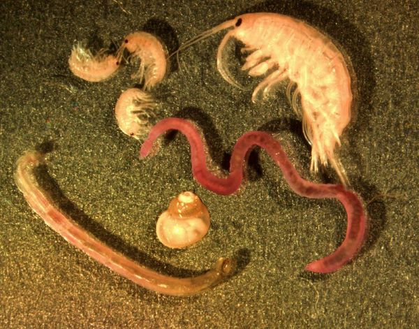

Fig. 1: Various benthic macroinvertebrates under a stereo microscope. Source: G. Carter via NOAA/GLERL

```r
pacman::p_load(leaflet)

leaflet() %>%
  addTiles() %>%  # Add default OpenStreetMap map tiles
  addMarkers(lng=-84.4110, lat=47.0515, popup="Turkey Lakes") %>%
  setView(lng=-84.4110, lat=47.0515, zoom=2)
```

[interactive chart not shown]

Figure 2. Interactive map of the Turkey Lakes study site

# Why biodiversity matters

In an ever-changing world, as biologists, we are often concerned with how organisms will be able to cope with disturbances and increasingly, global climate change. We often think of biodiversity as an important buffer to withstanding these changes, as more diversity may mean more success in environments persisting beyond the change. It is the idea of survival of the fittest, but with more security in sheer numbers.

# Types of data typically collected

Often times, biologists interested in collecting biodiversity data collect a standard set of responses. These often include:

1. The different kinds of species in a given area or environment
2. The number of each of these species (abundance)
3. Information about the area itself (i.e. habitat type, weather conditions, etc.)
4. If the work involves an setting up an experiment, collecting the control vs. experimental groups as well as metrics for repeatability + statistical power (replicates)
5. Of course, the time frame over which the data were collected

# Our simulated data

Here is a look at this simulated data:

```r
pacman::p_load(tidyverse, patchwork)
set.seed(222)
sim1 <- data.frame(
  species = sample(1:10, 20, replace=2),
  abundance = sample(0:200, 20, replace=2),
  time= 2001)
set.seed(723)
sim2 <- data.frame(
  species = sample(1:10, 20, replace=2),
  abundance = sample(0:200, 20, replace=2),
  time= 2009)
set.seed(117)
sim3 <- data.frame(
  species = sample(1:7, 20, replace=2),
  abundance = sample(0:200, 20, replace=2),
  time= 2020)
sim <- rbind(sim1, sim2, sim3)
head(sim)
```

```
##   species abundance time
## 1       2       149 2001
## 2       7       104 2001
## 3       8        42 2001
## 4       6         8 2001
## 5      10       191 2001
## 6       4       196 2001
```

# Ways to calculate diversity

Once we have collected our biodiversity data, there are several different ways to analyze and understand changes in community composition. Each of these metrics allow us to look at different aspects of the biodiversity data we collect.

To explore these different diversity metrics and how they are calculated, we have simulated a biodiversity dataset with 10 unique species and random abundances across 3 years. This will allow us to look at how diversity changes over time.

## Species Richness

Perhaps the simplest measure of biodiversity is species richness ($S$).

$S = \sum_{i=1}^{S}p_i^o$

You can calculate the species richness for each year by counting the number of unique species recorded in that year. Then you can look at how the number of different species in a community changes over time.

```r
pacman::p_load(codyn, kableExtra)
# Table showing the number of unique species
# Species richness calculation
richness_table <- sim %>%
  group_by(time) %>%
  summarise(richness=length(unique(species)))

kable(richness_table, col.names=c("Year", "Richness"), align="c") %>%
  kable_classic(full_width = F, html_font = "Cambria")
```

| Year | Richness |
| --- | --- |
| 2001 | 9 |
| 2009 | 9 |
| 2020 | 7 |

We can see in this table that across years, the number of species in the same area fluctuated, some years with more species, other years with less.

```r
shannon <- sim %>%
  group_by(time, species) %>%
  summarise(n=n()) %>%
  mutate(richness= case_when(time %in% c("2001", "2009") ~ 9,
                             TRUE~ 7),
    prop = n/sum(n),
    shannon= sum(prop/log(prop))) %>%
  as.data.frame()
```

## Shannon-Wiener Index (H)

Another metric we can use to analyze biodiversity is the Shannon-Wiener Index ($H$), which indexes across the sum of all relative proportions of species richness’s with an additional logarithmic transformation. This equation uses both the number of species in a specific area (richness) and relative abundance (evenness).

$H' = - \sum_{i=1}^{S}p_ilnp_i$

```r
shannon<-  sim %>%
    group_by(time, species) %>%
    summarise(n=n()) %>%
    mutate(prop = n/sum(n),
    shannon= sum(prop/log(prop))) %>% # Calculate Shannon's index
    summarise(shannon = mean(shannon))

kable(shannon, col.names=c("Year", "Shannon's Index"), align="c")%>%
  kable_classic(full_width = F, html_font = "Cambria")
```

| Year | Shannon’s Index |
| --- | --- |
| 2001 | -0.4990620 |
| 2009 | -0.5188309 |
| 2020 | -0.5458555 |

From our simulated dataset, we can see that the Shannon diversity decreases over time, which suggests that we lost important species as time went on and our biodiversity decreased.

## Simpson’s Index (D)

Another metric we can use to analyze biodiversity in the Simpson’s index ($D$) which indexes across the sum of all relative proportions of species’s richness with an additional square power transformation. This equation. Though very similar to the calculation in the Shannon-Wiener Index, the Simpson index is more focused on dominance of species as it highlights the proportion of species in a sample.

$\gamma = - \sum_{i=1}^{S}p_i^2$

```r
simpson<-  sim %>%
    group_by(time, species) %>%
    summarise(n=n()) %>%
    mutate(prop = n/sum(n),
    simpson = sum((prop)^2)) %>%
    summarise(simpson = mean(simpson)) # Calculate Simpson's index

kable(simpson, col.names=c("Year", "Simpson's Index"), align="c")%>%
  kable_classic(full_width = F, html_font = "Cambria")
```

| Year | Simpson’s Index |
| --- | --- |
| 2001 | 0.135 |
| 2009 | 0.145 |
| 2020 | 0.160 |

Interestingly, the Simpson index appears to increase over time. This is likely because Simpson’s index gives a higher weight to the more dominant species, so the value can actually increase even when biodiversity is decreasing.

## Evenness Index (E)

Additionally, we can think about the evenness of species across a given area. Evenness is a metric for assessing species dominance, if evenness is high, it means most species are of equal dominance. If evenness if low, it means some species are more dominant than others

$E = H / ln(S)$

```r
evenness<-  sim %>%
    group_by(time, species) %>%
    summarise(n=n()) %>%
    mutate(richness= case_when(time %in% c("2001", "2009") ~ 9,
                             TRUE~ 7),
           prop = n/sum(n),
    shannon= sum(prop/log(prop)),
    evenness = shannon/log(richness)) %>% # Calculate Shannon's evenness
    summarise(evenness = mean(evenness))

kable(evenness, col.names=c("Year", "Evenness"), align="c")%>%
  kable_classic(full_width = F, html_font = "Cambria")
```

| Year | Evenness |
| --- | --- |
| 2001 | -0.2271329 |
| 2009 | -0.2361301 |
| 2020 | -0.2805142 |

In our simulated dataset, we can see that evenness is low from the start and decreases over time, suggesting that more species become increasingly dominant over time.

# Visualizing species diversity

## Rank abundance curves with simulated data

One way to visualize biodiversity data is to make a Rank Abundance Curve (RAC). On the y-axis we have the abundance of each species, and species, ranked by abundance on the x-axis. Using RACs, we can visualize relative abundances, changes in species dominance, and overall changes in community composition with species loss and gain.

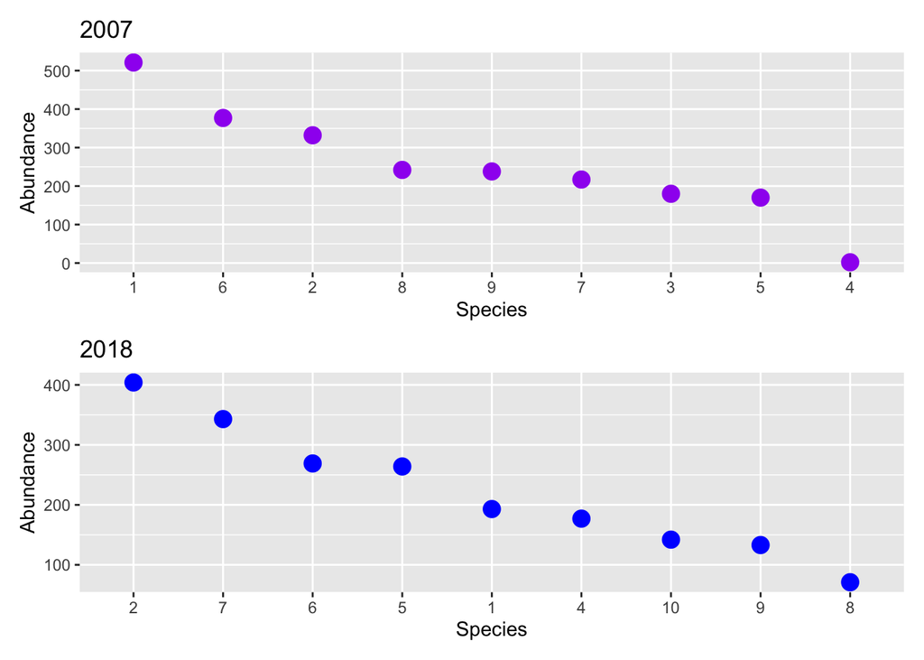

```r
library(tidyverse)
# Code or exercise on calculating species richness?
#before
pacman::p_load(tidyverse, patchwork)
set.seed(2)
data_2007 <- data.frame(
  species = sample(1:10, 20, replace=2),
  abundance = sample(0:200, 20, replace=2),
  time= 2007)

data_2018 <- data.frame(
  species = sample(1:10, 20, replace=2),
  abundance = sample(0:200, 20, replace=2),
  time= 2018)

data <- rbind(data_2007, data_2018) %>%
  group_by(species, time) %>%
  summarise(abundance= sum(abundance))


#2007
a<- data %>%
  filter(time == 2007 ) %>%
ggplot( aes(x=reorder(species, -abundance), y=abundance))+
  geom_point(size=4, colour="purple")+
  ggtitle("2007")+
  labs(x="Species", y="Abundance")

#2007
b<- data %>%
  filter(time == 2018 ) %>%
ggplot( aes(x=reorder(species, -abundance), y=abundance))+
  geom_point(size=4, colour="blue")+
  ggtitle("2018")+
  labs(x="Species", y="Abundance")


a / b
```

We can see here between 2007 and 2018 in our simulated community, there were differences in absolute abundance as well as which species were dominant, which species disappeared, and which species were new. For instance, in 2007, species 2 was the third most abundant species, but it 2018, it was the most abundant species. However, species 3 is lost by 2018, while species 10 is gained in 2018.

## Rank abundance curves with Turkey lakes invertebrate data

### Intro

In contrast, RACs in nature are rarely as evenly distributed as the simulated data. There is often few highly abundant species and many very rare species. Below, you can see the rank-abundance distribution from one of the catchments in our Turkey Lakes benthic invertebrate dataset from the year following logging treatments (1998).

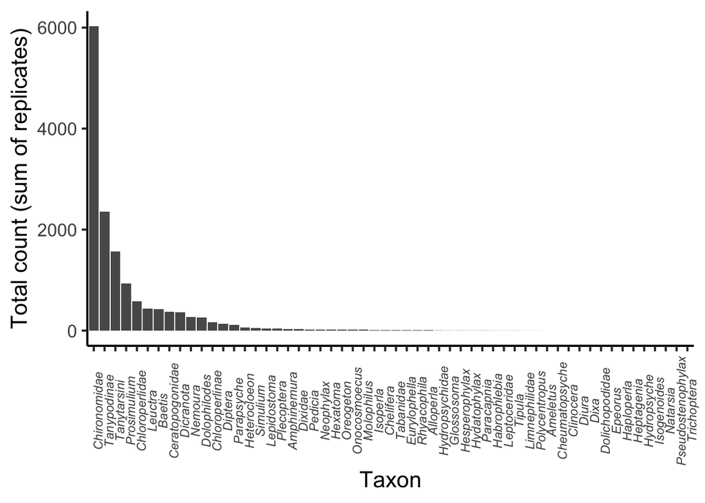

```r
source("R/RankAbundance/plotRankAbundance.R")
yr = 1998
plotRankAbundance(log=F,
                  select_catchment = c("34M",  "34U",    "34L"),
                  select_year      = c(yr,yr),
                  select_month     = c("june"))
```

### Log

To better visualize the distribution, the y-axis is typically log-transformed

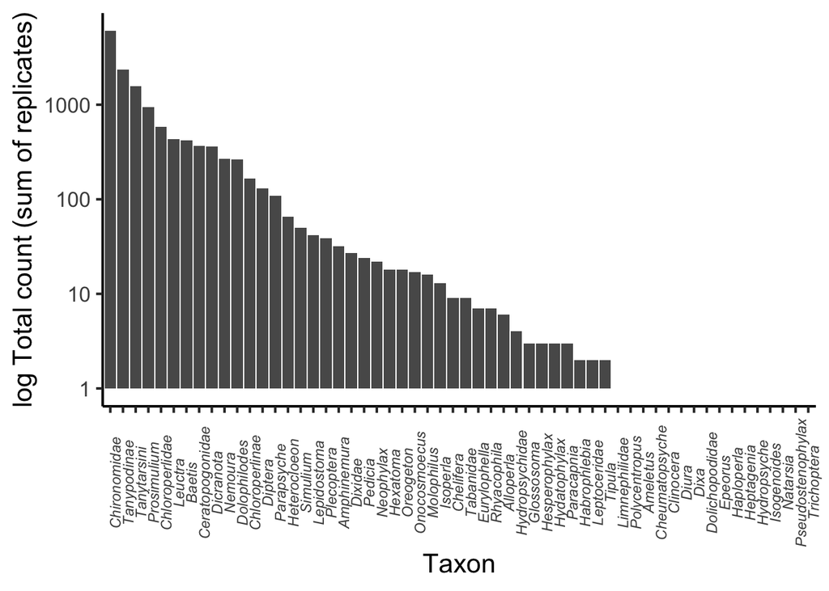

```r
plotRankAbundance(log=T,
                  select_catchment = c("34M",  "34U",    "34L"),
                  select_year      = c(yr,yr),
                  select_month     = c("june"))
```

### Rank

Because most classic metrics of biodiversity do not take the species identity into account, we can drop species names from the x-axis, and simply refer to it’s rank in the community. This is where the term **rank**-abundance comes from.

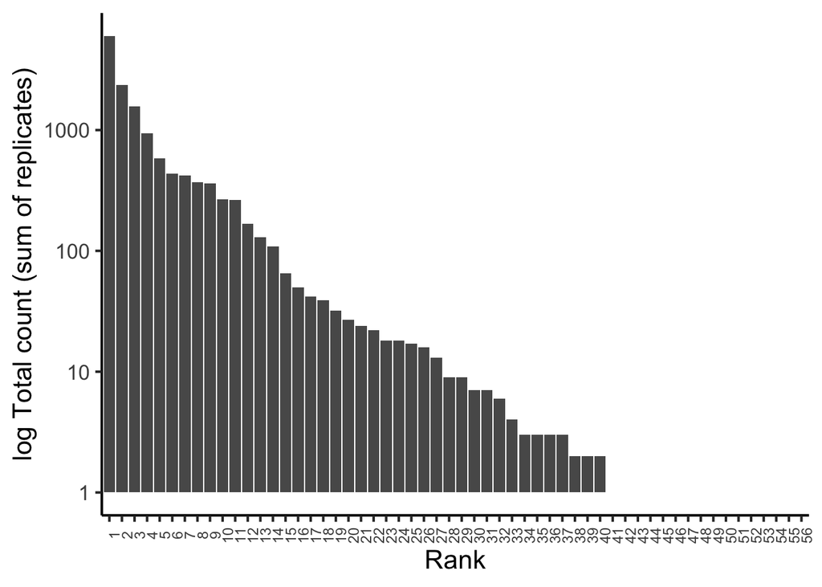

```r
plotRankAbundance(log=T,
                  select_catchment = c("34M",  "34U",    "34L"),
                  select_year      = c(yr,yr),
                  select_month     = c("june"),
                  SpName           = F)
```

### Curve

Finally, instead of using bars to represent abundances, we can simply use a lines to trace the distribution. This allows us to compare multiple distributions, in this case, from different three different sites with three levels of logging intensity.

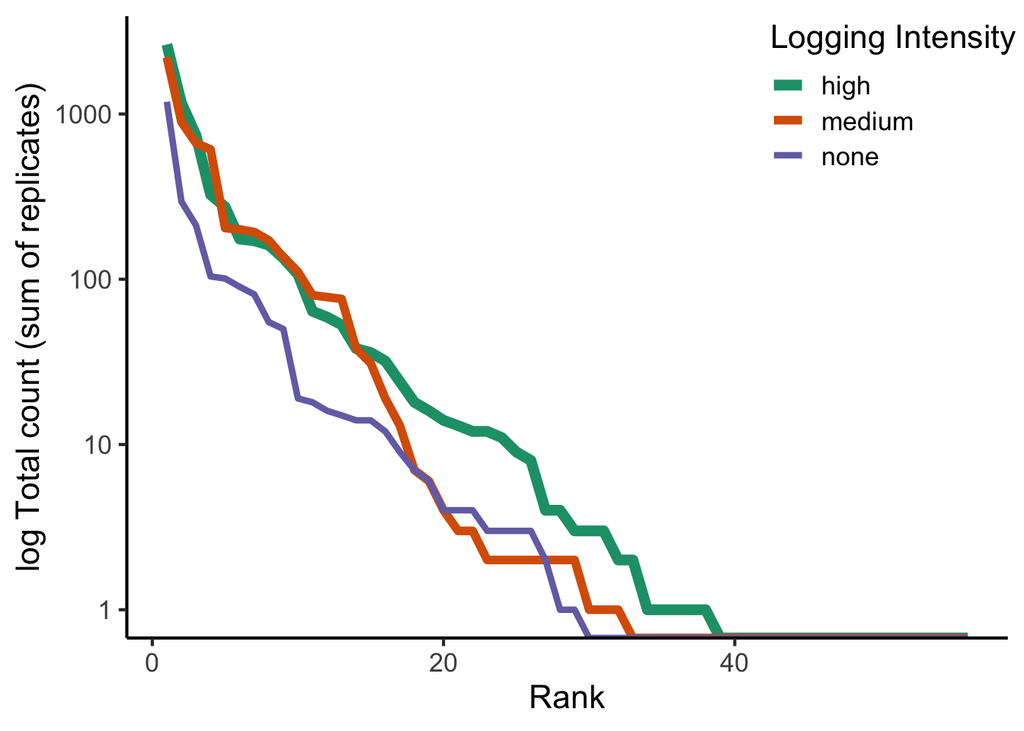

```r
source("R/RankAbundance/plotRAC.R")
df <- rankSpecies() %>%
  filter(year==yr)
ComparisonPlot = df %>%
  plotRAC(facets = F) +  theme(legend.position = c(0.87,0.87))
ComparisonPlot
```

### Species Richness

We can compare species richness by comparing the maximum rank.

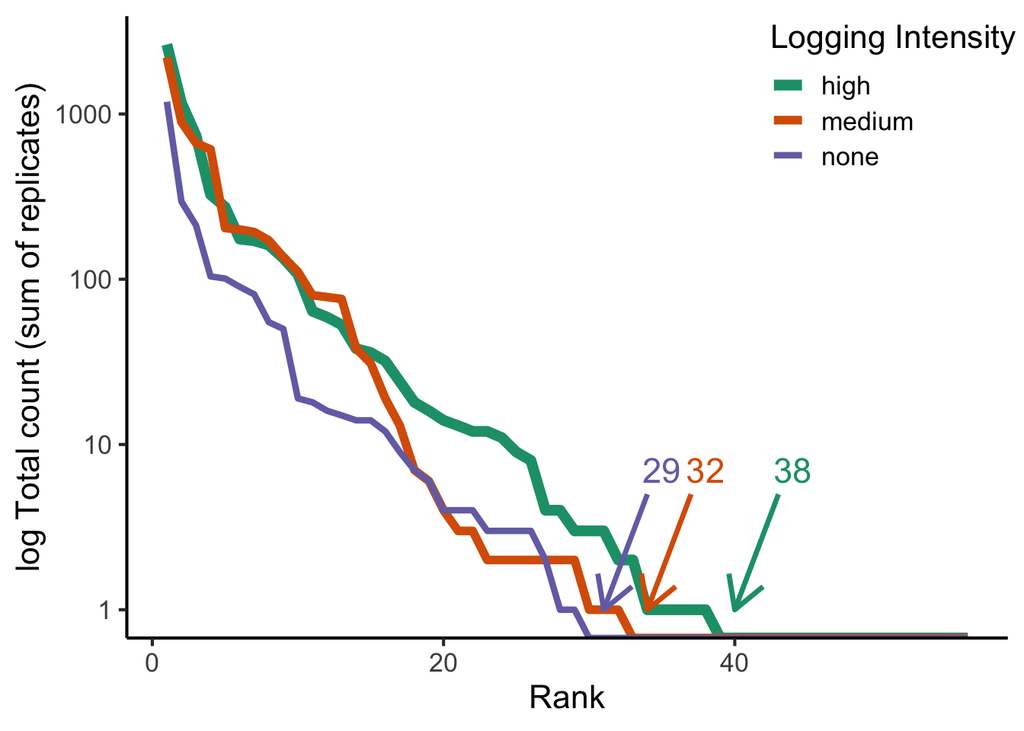

```r
dfRank = df %>%
  filter(TotalCount > 0)
annotations = dfRank %>% summarise(maxRank = max(Rank))

annotations$xend = c(40, 31, 34)
annotations$yend = rep(1, 3)
annotations$x    = annotations$xend + 3
annotations$y    = rep(5, 3)

ComparisonPlot +
  geom_segment(data = annotations, aes(yend=yend, xend=xend, x=x, y=y), size=1.2, arrow = arrow(), show.legend = FALSE) +
  geom_text(data = annotations, aes(x = x+1, y=y+2, label=maxRank), size=6, show.legend = FALSE)
```

### Evenness

The biodiversity metrics described (Shannon, Simpson, etc.) also incorporate community evenness, which can be thought of as the slope of rank-abundance curve. For example, a community with one very dominant species and a rapid drop-off in species abundance will have a lower evenness than a community where more species are common. In the plot below, the community at the site of “medium” logging (orange) is less even than the other two since it has a steeper average slope.

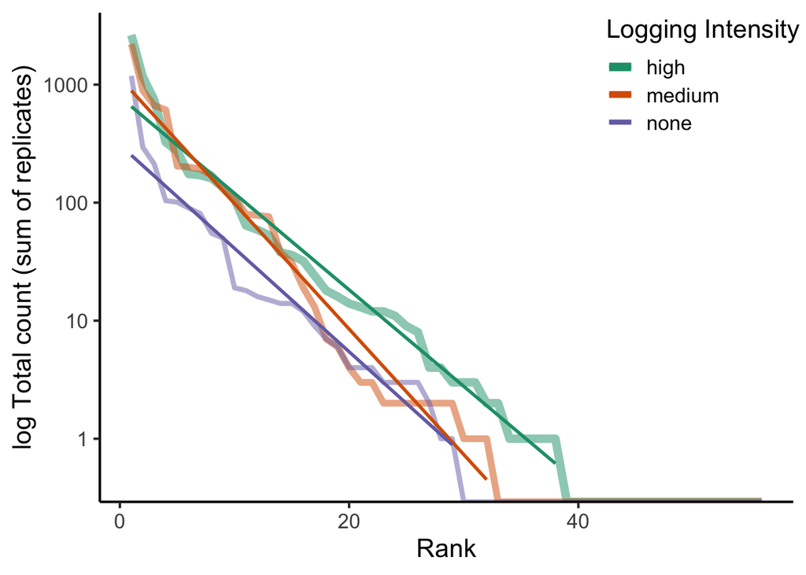

```r
q = {ComparisonPlot +  geom_smooth(method=lm, se=FALSE, data=dfRank) }%>%
  ggplot_build()
q$data[[1]]$alpha = 0.5

ggplot_gtable(q) %>%
  plot
```

### More models

Several models have been developed to understand rank-abundance curves (e.g. log-normal, broken stick model). The `radfit` function from the `vegan` `R` package allows fitting of these different curve models (see https://search.r-project.org/CRAN/refmans/vegan/html/radfit.html)

# `codyn` tutorial

## Load Packages

We will be using the `codyn` package for this tutorial. We will also use `ggplot2` and `dplyr` for plotting and cleaning.

```r
library(ggplot2)
library(codyn)
library(dplyr)
```

## Load Data

These data are from the Turkey Lakes watershed experiment. This dataset contains the abundances of benthic invertebrate species measured in the May and June from 1995 to 2001. They recorded the type and number of invertebrates in an area of the stream, with 10 replicates per sampling event. These forests next to these streams were logged in 1997 with varying harvest intensities, with low, medium, and high intensity harvest and a control stream with no forest harvest. We will using the `codyn` package to analyze the diversity of these benthic invertebrates over time.

```r
data<-read.csv("stream_invertebrates.csv")
head(data)
```

```
##   year   species treatment replicate abundance
## 1 1995 Alloperla   control         1         0
## 2 1995 Alloperla   control         2         0
## 3 1995 Alloperla   control         3         4
## 4 1995 Alloperla   control         4         3
## 5 1995 Alloperla   control         5         3
## 6 1995 Alloperla   control         6         3
```

For many functions, the `codyn` package can only look at data from one stream at a time. So first we will separate each stream into it’s own data frame.

```r
# high intensity logging treatment
subset_codyn_high <- data %>%
  filter(treatment == "high")
# medium intensity logging treatment
subset_codyn_med <- data %>%
  filter(treatment == "medium")
# low intensity logging treatment
subset_codyn_low <- data %>%
  filter(treatment == "low")
# control stream (no logging)
subset_codyn_ctrl <- data %>%
  filter(treatment=="control")
```

## Using the `codyn` package to analyze diversity data over time

Ecologists are often interested in how diversity changes over time in one place. This is particularly interesting when you are looking at how species diversity responds to environmental change. This environmental change can be a single disturbance event such as a forest fire or more long-term change such as temperature increases due to climate change. The Turkey Lakes dataset provides us with an opportunity to look at how the diversity of benthic invertebrates changes over time and in response to logging.

The `codyn` package allows us to analyze the change in biodiversity over time using different metrics.

## Using `community_structure()`

`community_structure()` is a function in the package `codyn` that calculates species richness and evenness.

### Species Richness and Evenness

For example, we can use `community_structure()` to look at the change in species richness and evenness over time in one of the Turkey Lake streams. We will choose the stream with high logging intensity as an example. This function can only look at one stream at a time so make sure to subset out the stream that you are interested in.

Let’s take a look at the high intensity logging stream data.

```r
head(subset_codyn_high)
```

```
##   year     species treatment replicate abundance
## 1 1995 Amphinemura      high         1         9
## 2 1995 Amphinemura      high         2        24
## 3 1995 Amphinemura      high         3        53
## 4 1995 Amphinemura      high         4        15
## 5 1995 Amphinemura      high         5        59
## 6 1995 Amphinemura      high         6        37
```

As you can see, there is a column for year, species, replicate, and abundance.

The community structure function has five arguments. The first is `df` where you put in the data frame of interest, in our case `subset_codyn_high`. The `time.var` argument is where you put in your time variable (`year`), the abundance.var argument is where you put the column that holds the abundance variable (`abundance`) and the `replicate.var` argument holds the column with the replicates (`replicate`). In the `metric` argument, you can specify the metric of evenness that you want the function to calculate. There are three possible metrics: `Evar`, `SimpsonEvenness`, and `EQ`, which all calculate evenness in different ways. We will use Simpson’s Evenness in this tutorial. Remember, if you ever need a refresher on the syntax you can type `?community_structure` into the R script.

```r
richness_high<-community_structure(df=subset_codyn_high, time.var="year", abundance.var="abundance", replicate.var="replicate", metric="SimpsonEvenness")
```

We can take a look at the output.

```r
head(richness_high)
```

```
##   year replicate richness SimpsonEvenness
## 1 1995         1       17       0.2210248
## 2 1996         1       11       0.5785671
## 3 1997         1       16       0.3436584
## 4 1998         1       18       0.2786702
## 5 1999         1       15       0.3540228
## 6 2001         1       23       0.2661854
```

As you can see, this returns a data frame with the year, replicate, richness calculation, and evenness measure. It calculates richness and evenness separately for each replicate sample in the stream, so we have a measure of variability within samples as well as variability across years.

#### Plot species richness

We can plot this data frame to see the changes over time.

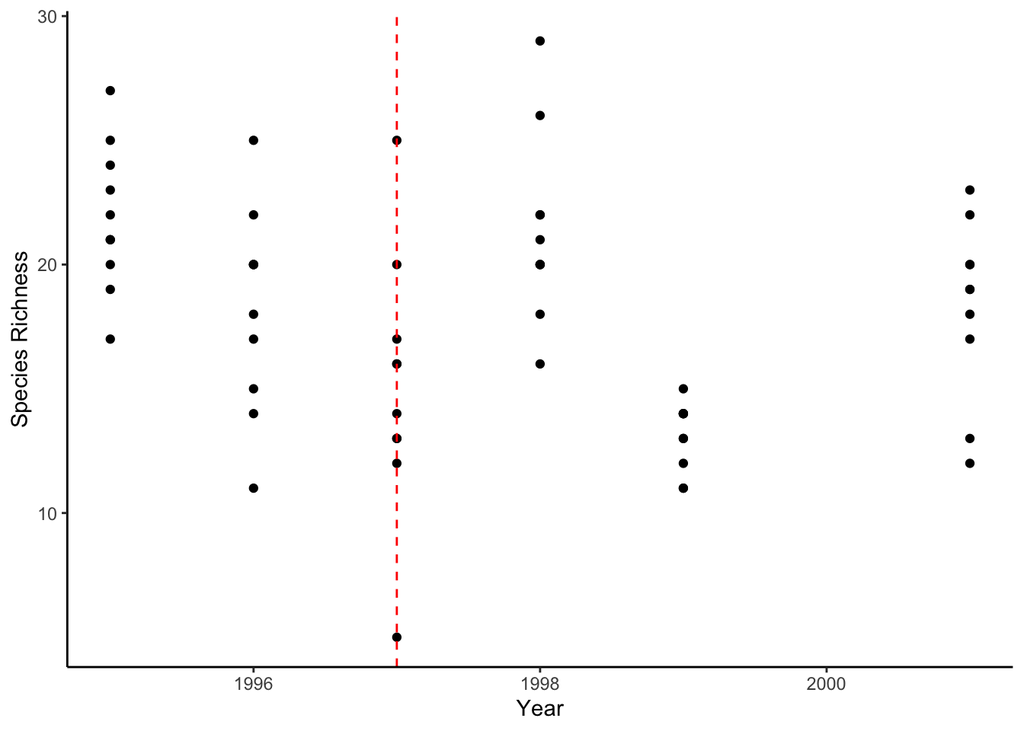

```r
ggplot()+
  geom_point(richness_high, mapping=aes(x=year, y=richness))+
  theme_classic()+
  labs(y="Species Richness", x="Year")+
  geom_vline(xintercept=1997, linetype=2, color="red")
```

Here is a plot of species richness, with a different value for each replicate. The red line is the year that the streams were logged. Do you see any change? Do you think there are any significant patterns? How does the variability between replicates compare to the variability between years?

#### Plot species evenness

We can also plot species evenness over time.

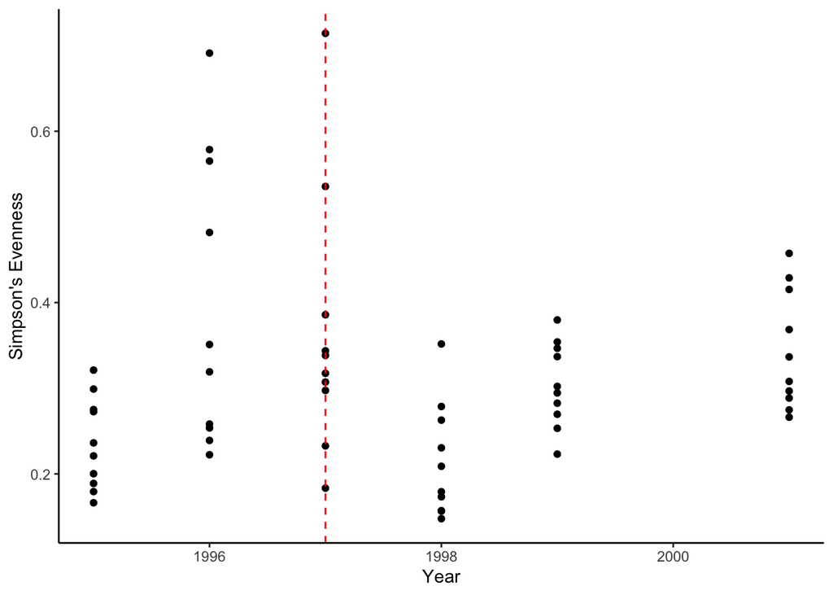

```r
ggplot()+
  geom_point(richness_high, mapping=aes(x=year, y=SimpsonEvenness))+
  theme_classic()+
  labs(y="Simpson's Evenness", x="Year")+
  geom_vline(xintercept=1997, linetype=2, color="red")
```

Do you see any patterns in the evenness between years?

## Using `community_diversity()`

### Shannon’s diversity

Species richness and evenness are very simple ways to look at species diversity. However, as you learned from the rank abundance curves, species have different abundances within the community, with some species having very high abundance and most species having low abundance. Species richness does not take into account the relative abundances of each species, which limits the inferences we can make. The Shannon-Weiner diversity metric does take into account these relative abundances when calculating the diversity of a community and allows us to make more meaningful inferences about how biodiversity is changing over time.

The `codyn` package allows you to calculate the Shannon diversity index for a single site over time using the `community_diversity()` function. We will again use the data from the stream with the high logging intensity. Luckily, this function has the exact same syntax as the `community_structure()` function! The only difference is that the options for the `metric` argument are `Shannon` and `InverseSimpson`. We will first use `Shannon`.

```r
shannon_div_high<-community_diversity(df=subset_codyn_high, time.var="year", abundance.var="abundance", replicate.var="replicate", metric="Shannon")
```

Let’s take a look at the output for this function.

```r
head(shannon_div_high)
```

```
##   year replicate  Shannon
## 1 1995         1 1.836002
## 2 1996         1 2.044210
## 3 1997         1 2.107977
## 4 1998         1 2.016146
## 5 1999         1 1.948510
## 6 2001         1 2.297970
```

You can see it gives us a data frame of `year`, `replicate`, and `Shannon`, which is our measure of Shannon diversity.

#### Plot Shannon’s diversity

We can plot these to see change over time.

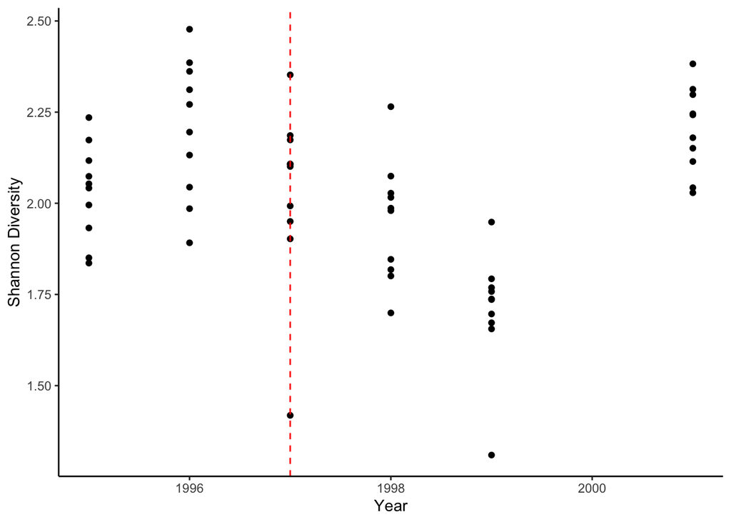

```r
ggplot()+
  geom_point(shannon_div_high, mapping=aes(x=year, y=Shannon))+
  theme_classic()+
  labs(y="Shannon Diversity", x="Year")+
  geom_vline(xintercept=1997, linetype=2, color="red")
```

### Simpson’s diversity

We can also use the same function to calculate Simpson’s diversity by simply changing the `metric` argument to `InverseSimpson`.

```r
simpson_div_high<-community_diversity(df=subset_codyn_high, time.var="year", abundance.var="abundance", replicate.var="replicate", metric="InverseSimpson")
```

We can look at the output.

```r
head(simpson_div_high)
```

```
##   year replicate InverseSimpson
## 1 1995         1       3.757421
## 2 1996         1       6.364238
## 3 1997         1       5.498534
## 4 1998         1       5.016063
## 5 1999         1       5.310341
## 6 2001         1       6.122265
```

#### Plot Simpson’s diversity

And then plot.

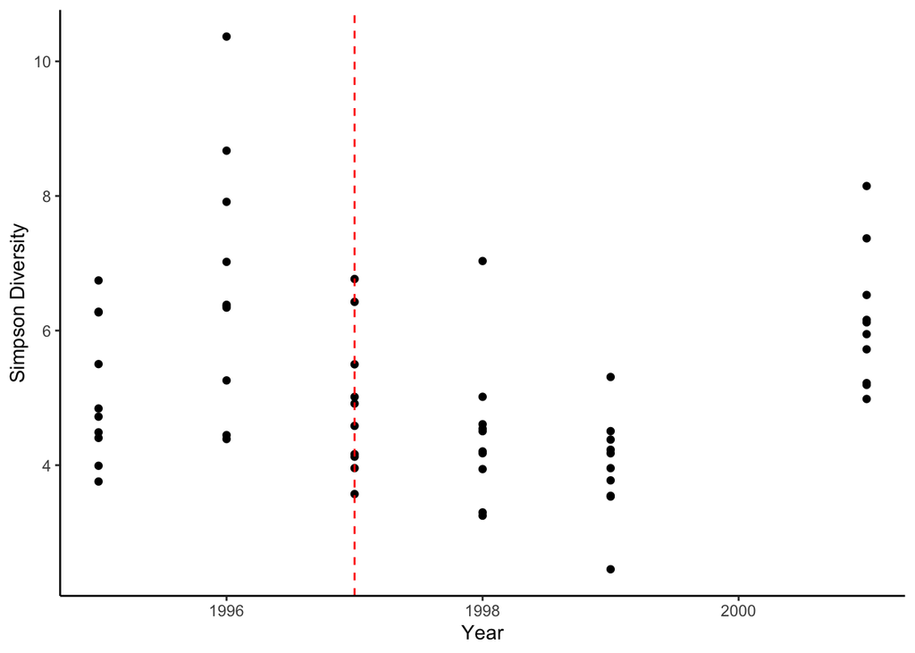

```r
ggplot()+
  geom_point(simpson_div_high, mapping=aes(x=year, y=InverseSimpson))+
  theme_classic()+
  labs(y="Simpson Diversity", x="Year")+
  geom_vline(xintercept=1997, linetype=2, color="red")
```

How do these patterns compare to the patterns of Shannon’s diversity over time? How do the values compare?

## Activity

# References

I got the equations from this paper: DOI:10.1007/s10531-016-1261-0